```python
import pandas as pd
import os
import pyodbc
import kagglehub

import plotly.express as px
import matplotlib.pyplot as plt
import seaborn as sns

from sqlalchemy import create_engine
from sqlalchemy.types import NVARCHAR
from IPython.display import HTML
import urllib
```

# Iranian Cosmetics & Personal Care Sales Dataset

```python
path = kagglehub.dataset_download("hosseinbadrnezhad/iranian-cosmetics-and-personal-care-sales-dataset")

print("Path to dataset files:", path)
```

```
Path to dataset files: C:\Users\USER\.cache\kagglehub\datasets\hosseinbadrnezhad\iranian-cosmetics-and-personal-care-sales-dataset\versions\1
```

```python
print(os.listdir(path))
```

```
['customers.csv', 'Invoices.csv', 'products.csv']
```

```python
cus = pd.read_csv(os.path.join(path, "customers.csv"))
inv = pd.read_csv(os.path.join(path, "Invoices.csv"))
pro = pd.read_csv(os.path.join(path, "Products.csv"))
```

```python
cus.head(4)
```

|  | CustomerId | CustomerName | Segment | Country | Region | State | City | PostalCode |
| --- | --- | --- | --- | --- | --- | --- | --- | --- |
| 0 | 1 | ریحانه صادقی | Corporate | Iran | Ahvaz | Khuzestan | Ahvaz | 61357 |
| 1 | 2 | نرگس قاسمی | Consumer | Iran | Tabriz | East Azerbaijan | Tabriz | 51666 |
| 2 | 3 | علی رضایی | Home Office | Iran | Karaj | Alborz | Karaj | 31485 |
| 3 | 4 | سارا احمدی | Home Office | Iran | Qom | Qom | Qom | 37156 |

```python
inv.head(4)
```

|  | InvoiceId | OrderDate | ProductId | CustomerId | ShipMode | Quantity | Sales | Profit | Discount | TotalAmount |
| --- | --- | --- | --- | --- | --- | --- | --- | --- | --- | --- |
| 0 | 1 | 2025-09-24 | 336 | 1052 | Same Day | 4 | 1800000 | 368000 | 0.00 | 1800000 |
| 1 | 2 | 2025-03-20 | 376 | 1682 | Standard Class | 1 | 320000 | 103000 | 0.00 | 320000 |
| 2 | 3 | 2025-10-18 | 174 | 1862 | Second Class | 2 | 360000 | 86000 | 0.00 | 360000 |
| 3 | 4 | 2025-10-20 | 425 | 379 | Standard Class | 1 | 680000 | 138000 | 0.05 | 646000 |

```python
pro.head(4)
```

|  | ProductId | Category | Sub-Category | ProductName |
| --- | --- | --- | --- | --- |
| 0 | 1 | آرایشی | مراقبت پوست | سرم هیدرودرم مدل 436 |
| 1 | 2 | بهداشتی | مراقبت مو | شامپو آردن مدل 981 |
| 2 | 3 | بهداشتی | مراقبت بدن | کرم آردن مدل 109 |
| 3 | 4 | بهداشتی | بهداشت شخصی | پنکیک هیدرودرم مدل 791 |

**CHECKING SHAPE**

```python
CUS = cus.shape
INV = inv.shape
PRO = pro.shape
print(CUS,INV,PRO)
```

```
(2500, 8) (14586, 10) (500, 4)
```

**CHECKING NULLs**

```python
CUS = cus.isnull().sum()
INV = inv.isnull().sum()
PRO = pro. isnull().sum()
print(CUS,INV,PRO)
```

```
CustomerId      0
CustomerName    0
Segment         0
Country         0
Region          0
State           0
City            0
PostalCode      0
dtype: int64 InvoiceId      0
OrderDate      0
ProductId      0
CustomerId     0
ShipMode       0
Quantity       0
Sales          0
Profit         0
Discount       0
TotalAmount    0
dtype: int64 ProductId       0
Category        0
Sub-Category    0
ProductName     0
dtype: int64
```

**CHECKING DUPLICATES**

```python
CUS = cus.duplicated().sum()
INV = inv.duplicated().sum()
PRO = pro. duplicated().sum()
print(CUS,INV,PRO)
```

```
0 0 0
```

**CHECKING NEGATIVE VALUES**

```python
(inv["Sales"] < 0).sum()
```

```
np.int64(0)
```

```python
(inv["Profit"] < 0).sum()
```

```
np.int64(0)
```

**CHECKING CONSISTENCY**

```python
cus.groupby("CustomerId")["CustomerName"].nunique().max()
```

```
1
```

```python
cus.groupby("CustomerId")["City"].nunique().max()
```

```
1
```

```python
inv.groupby("InvoiceId")["OrderDate"].nunique().max()
```

```
1
```

**CHECKING TEXT FORMATTING**

```python
cus["CustomerName"].str.strip().ne(cus["CustomerName"]).sum()
cus["Segment"].str.strip().ne(cus["Segment"]).sum()
cus["Country"].str.strip().ne(cus["Country"]).sum()
cus["Region"].str.strip().ne(cus["Region"]).sum()
cus["State"].str.strip().ne(cus["State"]).sum()
cus["City"].str.strip().ne(cus["City"]).sum()
```

```
np.int64(0)
```

```python
inv["ShipMode"].str.strip().ne(inv["ShipMode"]).sum()
```

```
np.int64(0)
```

```python
pro["Category"].str.strip().ne(pro["Category"]).sum()
pro["Sub-Category"].str.strip().ne(pro["Sub-Category"]).sum()
pro["ProductName"].str.strip().ne(pro["ProductName"]).sum()
```

```
np.int64(0)
```

**CHECKING DATE VALIDITY**

```python
inv["OrderDate"].min(), inv["OrderDate"].max()
```

```
('2025-01-01', '2025-12-31')
```

**CHECKING REFERENTIAL INTEGRITY**

```python
inv["CustomerId"].isin(cus["CustomerId"]).all()
```

```
np.True_
```

```python
inv["ProductId"].isin(pro["ProductId"]).all()
```

```
np.True_
```

**CHECKING UNIQUE VALUES**

```python
cus["Segment"].unique()
```

```
array(['Corporate', 'Consumer', 'Home Office'], dtype=object)
```

```python
cus["Region"].unique()
```

```
array(['Ahvaz', 'Tabriz', 'Karaj', 'Qom', 'Isfahan', 'Tehran', 'Mashhad',
       'Shiraz'], dtype=object)
```

```python
cus["State"].unique()
```

```
array(['Khuzestan', 'East Azerbaijan', 'Alborz', 'Qom', 'Isfahan',
       'Tehran', 'Khorasan Razavi', 'Fars'], dtype=object)
```

```python
inv["ShipMode"].unique()
```

```
array(['Same Day', 'Standard Class', 'Second Class', 'First Class'],
      dtype=object)
```

# DATA QUALITY CHECK

**CONCLUSION**

- The dataset has been successfully validated based on the checks performed.
- No data-quality issues were identified in the checks performed.
- The dataset is clean and ready to be imported into SQL Server for further analysis.

```python
conn = pyodbc.connect(
"DRIVER={ODBC Driver 17 for SQL Server};"
"SERVER=DESKTOP-KRJR07A\SQLEXPRESS;"
"DATABASE=STORE_DATA;"
"Trusted_connection=yes;"
)
print("CONNECT")
```

```
CONNECT
```

```python
params = urllib.parse.quote_plus(
    "DRIVER={ODBC Driver 17 for SQL Server};"
    r"SERVER=DESKTOP-KRJR07A\SQLEXPRESS;"
    "DATABASE=STORE_DATA;"
    "Trusted_Connection=yes;"
)

engine = create_engine(
    "mssql+pyodbc:///?odbc_connect=" + params
)
```

```python
from sqlalchemy.types import NVARCHAR

cus.to_sql("customers", engine, if_exists="replace", index=False, dtype={"CustomerName": NVARCHAR(255), "Segment": NVARCHAR(100),
"Country": NVARCHAR(100), "Region": NVARCHAR(100), "State": NVARCHAR(100), "City": NVARCHAR(100)})
```

```
142
```

```python
inv.to_sql("Invoices", engine  , if_exists="replace", index=False)
```

```
165
```

```python
pro.to_sql("Products", engine, if_exists="replace", index=False, dtype={"Category": NVARCHAR(100), "Sub-Category": NVARCHAR(100),
"ProductName": NVARCHAR(255)})
```

```
500
```

**CREATING DAY_NAME, MONTH_NAME, PROFIT_MARGIN**

```python
cursor = conn.cursor()

cursor.execute("""
ALTER TABLE Invoices
ADD DAY_NAME VARCHAR(20),
MONTH_NAME VARCHAR(20),
PROFIT_MARGIN DECIMAL(10, 2);
""")

conn.commit()
```

```python
cursor.execute("""
UPDATE Invoices
SET
DAY_NAME = DATENAME(WEEKDAY, OrderDate),
MONTH_NAME = DATENAME(MONTH, OrderDate),
PROFIT_MARGIN = Profit*100.0/NULLIF(Sales,.0);
""")

conn.commit()
```

```python
pd.read_sql("""
SELECT TOP 7 DAY_NAME, MONTH_NAME, PROFIT_MARGIN
FROM Invoices


""",engine)
```

|  | DAY_NAME | MONTH_NAME | PROFIT_MARGIN |
| --- | --- | --- | --- |
| 0 | Wednesday | September | 20.44 |
| 1 | Thursday | March | 32.19 |
| 2 | Saturday | October | 23.89 |
| 3 | Monday | October | 20.29 |
| 4 | Thursday | January | 25.47 |
| 5 | Tuesday | May | 23.04 |
| 6 | Sunday | November | 31.20 |

**CHECKING TABLE STRUCTURE**

```python
pd.read_sql("""
SELECT TABLE_NAME, COLUMN_NAME
FROM INFORMATION_SCHEMA.COLUMNS
WHERE TABLE_NAME IN ('customers', 'Invoices', 'products')
ORDER BY TABLE_NAME;

""", engine)
```

|  | TABLE_NAME | COLUMN_NAME |
| --- | --- | --- |
| 0 | customers | City |
| 1 | customers | Country |
| 2 | customers | CustomerId |
| 3 | customers | CustomerName |
| 4 | customers | PostalCode |
| 5 | customers | Region |
| 6 | customers | Segment |
| 7 | customers | State |
| 8 | Invoices | CustomerId |
| 9 | Invoices | DAY_NAME |
| 10 | Invoices | Discount |
| 11 | Invoices | InvoiceId |
| 12 | Invoices | MONTH_NAME |
| 13 | Invoices | OrderDate |
| 14 | Invoices | ProductId |
| 15 | Invoices | Profit |
| 16 | Invoices | PROFIT_MARGIN |
| 17 | Invoices | Quantity |
| 18 | Invoices | Sales |
| 19 | Invoices | ShipMode |
| 20 | Invoices | TotalAmount |
| 21 | Products | Category |
| 22 | Products | ProductId |
| 23 | Products | ProductName |
| 24 | Products | Sub-Category |

# INNER JOIN

```python
pd.read_sql("""
SELECT *
FROM customers AS C
INNER JOIN Invoices AS I
ON C.CustomerId = I.CustomerId
INNER JOIN products AS P
ON P.ProductId = I.ProductId
""",engine)
```

|  | CustomerId | CustomerName | Segment | Country | Region | State | City | PostalCode | InvoiceId | OrderDate | ... | Profit | Discount | TotalAmount | DAY_NAME | MONTH_NAME | PROFIT_MARGIN | ProductId | Category | Sub-Category | ProductName |
| --- | --- | --- | --- | --- | --- | --- | --- | --- | --- | --- | --- | --- | --- | --- | --- | --- | --- | --- | --- | --- | --- |
| 0 | 1052 | محمد اکبری | Consumer | Iran | Tabriz | East Azerbaijan | Tabriz | 51666 | 1 | 2025-09-24 | ... | 368000 | 0.00 | 1800000 | Wednesday | September | 20.44 | 336 | آرایشی | آرایش چشم | نرم‌کننده سینره مدل 259 |
| 1 | 1682 | سارا محمدی | Consumer | Iran | Tabriz | East Azerbaijan | Tabriz | 51666 | 2 | 2025-03-20 | ... | 103000 | 0.00 | 320000 | Thursday | March | 32.19 | 376 | بهداشتی | مراقبت مو | کرم شون مدل 263 |
| 2 | 1862 | ریحانه جعفری | Home Office | Iran | Ahvaz | Khuzestan | Ahvaz | 61357 | 3 | 2025-10-18 | ... | 86000 | 0.00 | 360000 | Saturday | October | 23.89 | 174 | آرایشی | آرایش صورت | پنکیک شون مدل 965 |
| 3 | 379 | فاطمه مرادی | Consumer | Iran | Tehran | Tehran | Tehran | 11111 | 4 | 2025-10-20 | ... | 138000 | 0.05 | 646000 | Monday | October | 20.29 | 425 | بهداشتی | مراقبت بدن | ریمل سینره مدل 802 |
| 4 | 1103 | مریم اکبری | Consumer | Iran | Tabriz | East Azerbaijan | Tabriz | 51666 | 5 | 2025-01-02 | ... | 326000 | 0.00 | 1280000 | Thursday | January | 25.47 | 434 | آرایشی | مراقبت پوست | ماسک هیدرودرم مدل 101 |
| ... | ... | ... | ... | ... | ... | ... | ... | ... | ... | ... | ... | ... | ... | ... | ... | ... | ... | ... | ... | ... | ... |
| 14581 | 1915 | پارسا رضایی | Corporate | Iran | Karaj | Alborz | Karaj | 31485 | 14582 | 2025-10-16 | ... | 694000 | 0.05 | 2584000 | Thursday | October | 25.51 | 471 | بهداشتی | مراقبت مو | شامپو هیدرودرم مدل 321 |
| 14582 | 1034 | الهام حسینی | Consumer | Iran | Tehran | Tehran | Tehran | 11111 | 14583 | 2025-12-22 | ... | 239000 | 0.05 | 1216000 | Monday | December | 18.67 | 132 | آرایشی | آرایش چشم | ماسک شون مدل 730 |
| 14583 | 258 | محمد جعفری | Corporate | Iran | Tehran | Tehran | Tehran | 11111 | 14584 | 2025-05-05 | ... | 280000 | 0.05 | 874000 | Monday | May | 30.43 | 200 | بهداشتی | بهداشت دهان | خمیر دندان هیدرودرم مدل 506 |
| 14584 | 1902 | امیر اکبری | Home Office | Iran | Isfahan | Isfahan | Isfahan | 81746 | 14585 | 2025-06-20 | ... | 161000 | 0.00 | 480000 | Friday | June | 33.54 | 113 | بهداشتی | بهداشت شخصی | دهان‌شویه مای مدل 570 |
| 14585 | 1575 | الهام مرادی | Home Office | Iran | Shiraz | Fars | Shiraz | 71946 | 14586 | 2025-01-26 | ... | 536000 | 0.05 | 1748000 | Sunday | January | 29.13 | 151 | آرایشی | آرایش صورت | دهان‌شویه هیدرودرم مدل 747 |

14586 rows × 25 columns

**VALIDATING FINAL DATASET AFTER INNER JOIN**

```python
pd.read_sql("""
SELECT COUNT(*) AS TOTAL_ROWS
FROM customers AS C
INNER JOIN Invoices AS I
ON C.CustomerId = I.CustomerId
INNER JOIN products AS P
ON P.ProductId = I.ProductId;

""", engine)
```

|  | TOTAL_ROWS |
| --- | --- |
| 0 | 14586 |

```python
pd.read_sql("""
SELECT TABLE_NAME,
COUNT(*) AS TOTAL_COLUMNS
FROM INFORMATION_SCHEMA.COLUMNS
WHERE TABLE_NAME IN ('customers', 'Invoices', 'products')
GROUP BY TABLE_NAME
ORDER BY TABLE_NAME;

""", engine)
```

|  | TABLE_NAME | TOTAL_COLUMNS |
| --- | --- | --- |
| 0 | customers | 8 |
| 1 | Invoices | 13 |
| 2 | Products | 4 |

**TOP 10 CUSTOMERS BY SALES AND PROFIT**

```python
pd.read_sql("""
SELECT TOP 10
C.CustomerId,
C.CustomerName,
SUM(I.Sales) AS TOTAL_SALES,
SUM(I.Profit) AS TOTAL_PROFIT
FROM customers AS C
INNER JOIN Invoices AS I
ON C.CustomerId = I.CustomerId
GROUP BY C.CustomerId, C.CustomerName
ORDER BY TOTAL_SALES DESC, TOTAL_PROFIT DESC;

""", engine)
```

|  | CustomerId | CustomerName | TOTAL_SALES | TOTAL_PROFIT |
| --- | --- | --- | --- | --- |
| 0 | 1377 | مریم جعفری | 26400000 | 6513000 |
| 1 | 250 | محمد اکبری | 24840000 | 6341000 |
| 2 | 1215 | نوید صادقی | 24640000 | 6021000 |
| 3 | 2423 | رضا اکبری | 24130000 | 6327000 |
| 4 | 2456 | نوید محمدی | 24040000 | 6718000 |
| 5 | 2334 | پارسا رضایی | 23150000 | 5740000 |
| 6 | 2157 | لیلا احمدی | 22890000 | 6083000 |
| 7 | 2123 | امیر حسینی | 22640000 | 5778000 |
| 8 | 130 | محمد قاسمی | 22130000 | 4994000 |
| 9 | 320 | سینا رضایی | 21920000 | 5853000 |

**SALES, PROFIT AND PROFIT MARGIN BY SEGMENT**

```python
pd.read_sql("""
SELECT C.Segment,
SUM(I.Sales) AS TOTAL_SALES,
SUM(I.Profit) AS TOTAL_PROFIT,
ROUND(SUM(I.Profit) * 100.0 / SUM(I.Sales),2) AS PROFIT_MARGIN
FROM customers AS C
INNER JOIN Invoices AS I
ON C.CustomerId = I.CustomerId
GROUP BY C.Segment
ORDER BY TOTAL_SALES DESC, TOTAL_PROFIT DESC;

""", engine)
```

|  | Segment | TOTAL_SALES | TOTAL_PROFIT | PROFIT_MARGIN |
| --- | --- | --- | --- | --- |
| 0 | Corporate | 6300820000 | 1627109000 | 25.82 |
| 1 | Home Office | 6291210000 | 1619509000 | 25.74 |
| 2 | Consumer | 6252380000 | 1602442000 | 25.63 |

**TOP 10 PRODUCTS BY SALES, PROFIT AND PROFIT MARGIN**

```python
pd.read_sql("""
SELECT TOP 10 P.ProductName,
SUM(I.Sales) AS TOTAL_SALES,
SUM(I.Profit) AS TOTAL_PROFIT,
ROUND(SUM(I.Profit) * 100.0 / SUM(I.Sales), 2) AS PROFIT_MARGIN
FROM Products AS P
INNER JOIN Invoices AS I
ON P.ProductId = I.ProductId
GROUP BY P.ProductName
ORDER BY TOTAL_SALES DESC;

""", engine)
```

|  | ProductName | TOTAL_SALES | TOTAL_PROFIT | PROFIT_MARGIN |
| --- | --- | --- | --- | --- |
| 0 | صابون سینره مدل 716 | 90480000 | 21933000 | 24.24 |
| 1 | کرم سینره مدل 501 | 74240000 | 19535000 | 26.31 |
| 2 | ریمل شون مدل 673 | 70830000 | 17641000 | 24.91 |
| 3 | لوسیون سی‌گل مدل 987 | 69760000 | 18161000 | 26.03 |
| 4 | ماسک شون مدل 142 | 67720000 | 17059000 | 25.19 |
| 5 | صابون لافارر مدل 147 | 65750000 | 17394000 | 26.45 |
| 6 | ماسک شون مدل 730 | 65700000 | 18392000 | 27.99 |
| 7 | خمیر دندان مای مدل 210 | 64870000 | 16575000 | 25.55 |
| 8 | لوسیون آردن مدل 938 | 64220000 | 16491000 | 25.68 |
| 9 | تونر سینره مدل 495 | 63430000 | 16808000 | 26.50 |

**SALES & PROFIT BY REGION**

```python
pd.read_sql("""
SELECT C.Region,
SUM(I.Sales) AS TOTAL_SALES,
SUM(I.Profit) AS TOTAL_PROFIT
FROM customers AS C
INNER JOIN Invoices AS I
ON C.CustomerId = I.CustomerId
INNER JOIN products AS P
ON P.ProductId = I.ProductId
GROUP BY C.Region
ORDER BY TOTAL_SALES DESC, TOTAL_PROFIT DESC;

""", engine)
```

|  | Region | TOTAL_SALES | TOTAL_PROFIT |
| --- | --- | --- | --- |
| 0 | Tehran | 2567320000 | 659726000 |
| 1 | Mashhad | 2497290000 | 641193000 |
| 2 | Isfahan | 2414870000 | 619446000 |
| 3 | Shiraz | 2397970000 | 618055000 |
| 4 | Karaj | 2335250000 | 601564000 |
| 5 | Ahvaz | 2219470000 | 569023000 |
| 6 | Tabriz | 2213660000 | 573983000 |
| 7 | Qom | 2198580000 | 566070000 |

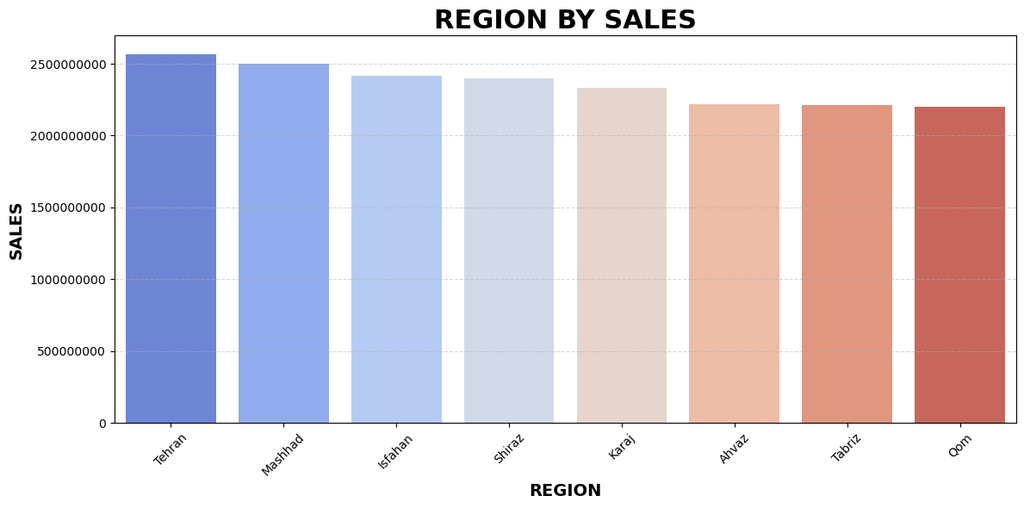

```python
REGION_BY_SALES_PROFIT = pd.read_sql("""
SELECT C.Region AS REGION,
SUM(I.Sales) AS TOTAL_SALES,
SUM(I.Profit) AS TOTAL_PROFIT
FROM customers AS C
INNER JOIN Invoices AS I
ON C.CustomerId = I.CustomerId
INNER JOIN products AS P
ON P.ProductId = I.ProductId
GROUP BY C.Region
ORDER BY TOTAL_SALES DESC, TOTAL_PROFIT DESC;

""", engine)

plt.figure(figsize=(12,6))
sns.barplot(data= REGION_BY_SALES_PROFIT, x= "REGION", y= "TOTAL_SALES", palette= "coolwarm", legend= False, hue= "REGION")
plt.title("REGION BY SALES", color= "black", fontsize= 22, fontweight= "bold")
plt.xlabel("REGION", color= "black", fontsize= 14, fontweight= "bold")
plt.ylabel("SALES", color= "black", fontsize= 14, fontweight= "bold")
plt.grid(axis="y", linestyle="--", alpha= 0.5)
plt.ticklabel_format(axis="y", style= "plain")
plt.xticks(rotation = 45)
plt.tight_layout()
plt.show()
```

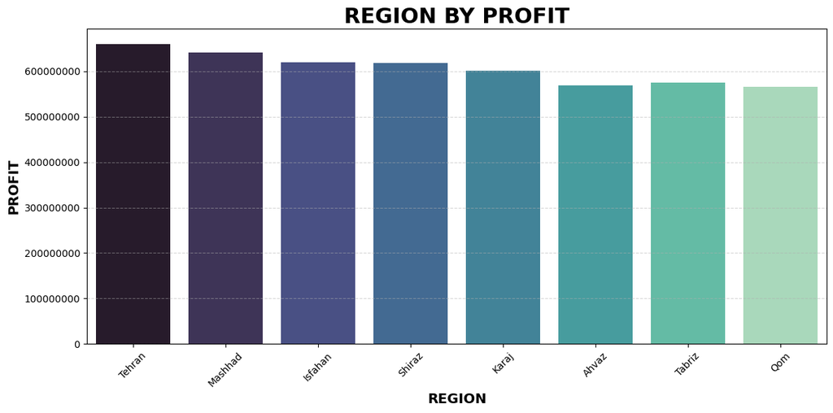

```python
REGION_BY_SALES_PROFIT = pd.read_sql("""
SELECT C.Region AS REGION,
SUM(I.Sales) AS TOTAL_SALES,
SUM(I.Profit) AS TOTAL_PROFIT
FROM customers AS C
INNER JOIN Invoices AS I
ON C.CustomerId = I.CustomerId
INNER JOIN products AS P
ON P.ProductId = I.ProductId
GROUP BY C.Region
ORDER BY TOTAL_SALES DESC, TOTAL_PROFIT DESC;

""", engine)

plt.figure(figsize=(12,6))
sns.barplot(data= REGION_BY_SALES_PROFIT, x= "REGION", y= "TOTAL_PROFIT", palette= "mako", legend= False, hue= "REGION")
plt.title("REGION BY PROFIT", color= "black", fontsize= 22, fontweight= "bold")
plt.xlabel("REGION", color= "black", fontsize= 14, fontweight= "bold")
plt.ylabel("PROFIT", color= "black", fontsize= 14, fontweight= "bold")
plt.grid(axis="y", linestyle="--", alpha= 0.5)
plt.ticklabel_format(axis="y", style= "plain")
plt.xticks(rotation = 45)
plt.tight_layout()
plt.show()
```

**SALES & PROFIT BY SHIPMODE**

```python
pd.read_sql("""
SELECT ShipMode,
SUM(Sales) AS TOTAL_SALES,
SUM(Profit) AS TOTAL_PROFIT
FROM Invoices
GROUP BY ShipMode
ORDER BY TOTAL_SALES DESC, TOTAL_PROFIT DESC;
""",engine)
```

|  | ShipMode | TOTAL_SALES | TOTAL_PROFIT |
| --- | --- | --- | --- |
| 0 | Same Day | 4911560000 | 1257929000 |
| 1 | Standard Class | 4746760000 | 1220834000 |
| 2 | Second Class | 4613140000 | 1188652000 |
| 3 | First Class | 4572950000 | 1181645000 |

```python
SHIPMODE = pd.read_sql("""
SELECT ShipMode,
SUM(Sales) AS TOTAL_SALES,
SUM(Profit) AS TOTAL_PROFIT
FROM Invoices
GROUP BY ShipMode
ORDER BY TOTAL_SALES DESC, TOTAL_PROFIT DESC;
""",engine)
```

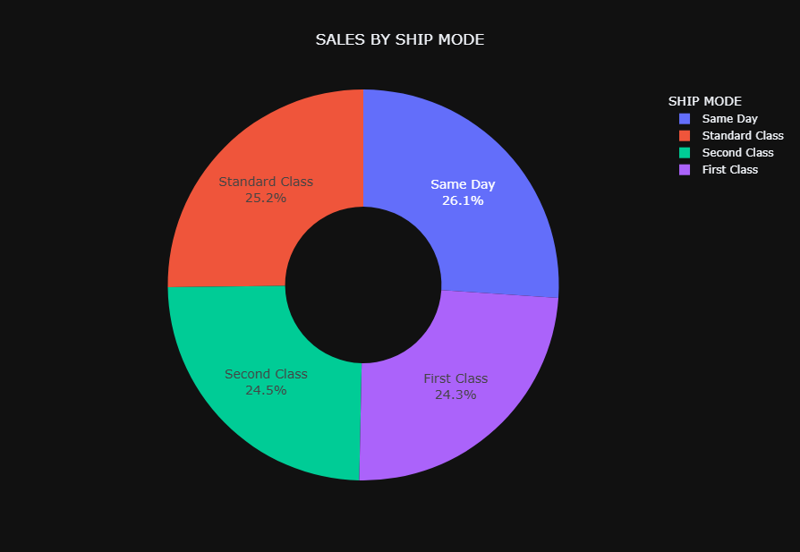

```python
fig = px.pie(SHIPMODE, names="ShipMode", values="TOTAL_SALES", title="SALES BY SHIP MODE", hole=0.4)

fig.update_traces(textinfo="percent+label", textposition="inside", textfont_size=14)
fig.update_layout(template="plotly_dark", title_x=0.5, height=600, width=900, legend_title="SHIP MODE")

fig.show()
```

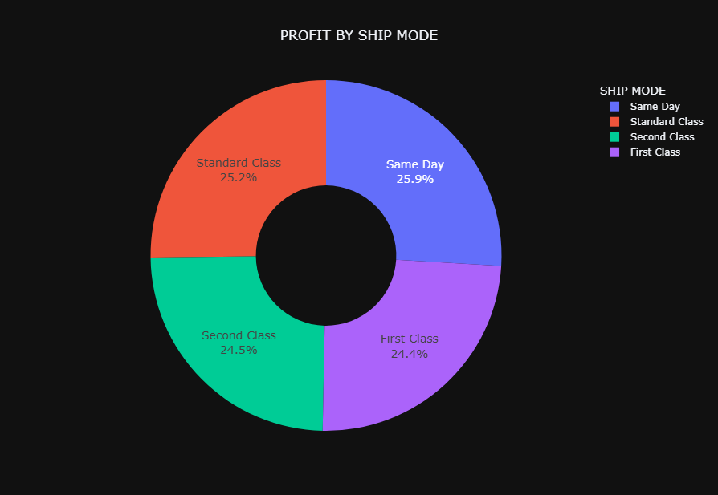

```python
fig = px.pie(SHIPMODE, names="ShipMode", values="TOTAL_PROFIT", title="PROFIT BY SHIP MODE", hole=0.4)

fig.update_traces(textinfo="percent+label", textposition="inside", textfont_size=14)
fig.update_layout(template="plotly_dark", title_x=0.5, height=600, width=900, legend_title="SHIP MODE")

fig.show()
```

**DAILY SALES & PROFIT**

```python
pd.read_sql("""
SELECT DAY_NAME,
SUM(Sales) AS TOTAL_SALES,
SUM(Profit) AS TOTAL_PROFIT
FROM Invoices
GROUP BY DAY_NAME
ORDER BY CASE DAY_NAME
WHEN 'Monday' THEN 1
WHEN 'Tuesday' THEN 2
WHEN 'Wednesday' THEN 3
WHEN 'Thursday' THEN 4
WHEN 'Friday' THEN 5
WHEN 'Saturday' THEN 6
WHEN 'Sunday' THEN 7
END;
""",engine)
```

|  | DAY_NAME | TOTAL_SALES | TOTAL_PROFIT |
| --- | --- | --- | --- |
| 0 | Monday | 2718370000 | 703085000 |
| 1 | Tuesday | 2676850000 | 688649000 |
| 2 | Wednesday | 2761470000 | 716163000 |
| 3 | Thursday | 2635330000 | 672089000 |
| 4 | Friday | 2784710000 | 712202000 |
| 5 | Saturday | 2597080000 | 671859000 |
| 6 | Sunday | 2670600000 | 685013000 |

```python
DAILY_SALES_PROFIT = pd.read_sql("""
SELECT DAY_NAME,
SUM(Sales) AS TOTAL_SALES,
SUM(Profit) AS TOTAL_PROFIT
FROM Invoices
GROUP BY DAY_NAME
ORDER BY CASE DAY_NAME
WHEN 'Monday' THEN 1
WHEN 'Tuesday' THEN 2
WHEN 'Wednesday' THEN 3
WHEN 'Thursday' THEN 4
WHEN 'Friday' THEN 5
WHEN 'Saturday' THEN 6
WHEN 'Sunday' THEN 7
END;
""",engine)
```

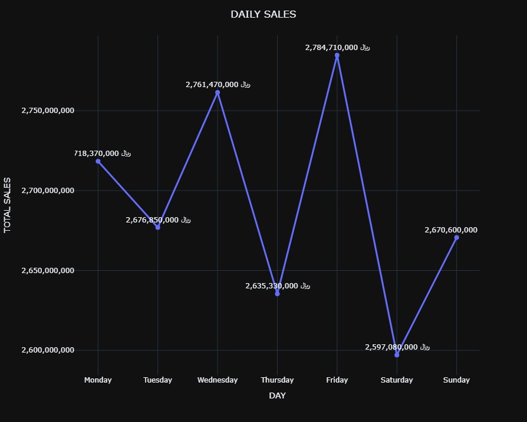

```python
fig = px.line(DAILY_SALES_PROFIT, x="DAY_NAME", y="TOTAL_SALES", markers=True, text="TOTAL_SALES")

fig.update_traces(texttemplate="﷼ %{text:,.0f}", textposition="top center", line=dict(width=3), marker=dict(size=8))
fig.update_layout(title="DAILY SALES", title_x=0.5, height=700, width=1100, xaxis_title="DAY", yaxis_title="TOTAL SALES", hovermode="x unified",
template="plotly_dark")
fig.update_yaxes(tickformat=",")

fig.show()
```

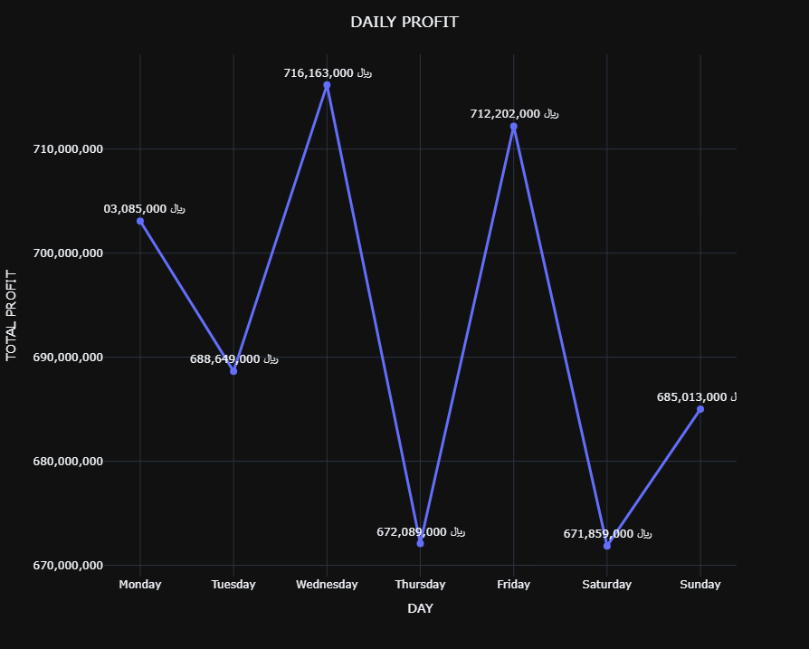

```python
fig = px.line(DAILY_SALES_PROFIT, x="DAY_NAME", y="TOTAL_PROFIT", markers=True, text="TOTAL_PROFIT")

fig.update_traces(texttemplate="ریال %{text:,.0f}", textposition="top center", line=dict(width=3), marker=dict(size=8))
fig.update_layout(title="DAILY PROFIT", title_x=0.5, height=700, width=1100, xaxis_title="DAY", yaxis_title="TOTAL PROFIT", hovermode="x unified",
template="plotly_dark")
fig.update_yaxes(tickformat=",")

fig.show()
```

**SALES & PROFIT BY YEAR, MONTH_NAME, CATEGORY & SUB-CATEGORY**

```python
pd.read_sql("""
SELECT MONTH_NUM, MONTH_NAME, YEAR, Category, [Sub-Category], TOTAL_SALES, TOTAL_PROFIT
FROM (SELECT MONTH(I.OrderDate) AS MONTH_NUM, I.MONTH_NAME, YEAR(I.OrderDate) AS YEAR, P.Category, P.[Sub-Category],
SUM(I.Sales) AS TOTAL_SALES, SUM(I.Profit) AS TOTAL_PROFIT,
ROW_NUMBER() OVER(PARTITION BY YEAR(I.OrderDate), MONTH(I.OrderDate) ORDER BY SUM(I.Sales) DESC, SUM(I.Profit) DESC) AS RN
FROM Invoices AS I
INNER JOIN Products AS P ON P.ProductId = I.ProductId
GROUP BY MONTH(I.OrderDate), I.MONTH_NAME, YEAR(I.OrderDate), P.Category, P.[Sub-Category]) AS A
WHERE RN = 1
ORDER BY YEAR, MONTH_NUM;
""", engine)
```

|  | MONTH_NUM | MONTH_NAME | YEAR | Category | Sub-Category | TOTAL_SALES | TOTAL_PROFIT |
| --- | --- | --- | --- | --- | --- | --- | --- |
| 0 | 1 | January | 2025 | آرایشی | مراقبت پوست | 266350000 | 69050000 |
| 1 | 2 | February | 2025 | آرایشی | آرایش صورت | 233170000 | 60730000 |
| 2 | 3 | March | 2025 | آرایشی | آرایش صورت | 262510000 | 65994000 |
| 3 | 4 | April | 2025 | آرایشی | مراقبت پوست | 224750000 | 56847000 |
| 4 | 5 | May | 2025 | آرایشی | آرایش صورت | 220680000 | 56920000 |
| 5 | 6 | June | 2025 | آرایشی | آرایش صورت | 233170000 | 60112000 |
| 6 | 7 | July | 2025 | بهداشتی | مراقبت مو | 288870000 | 74905000 |
| 7 | 8 | August | 2025 | آرایشی | آرایش صورت | 245990000 | 62110000 |
| 8 | 9 | September | 2025 | بهداشتی | مراقبت بدن | 242810000 | 62919000 |
| 9 | 10 | October | 2025 | آرایشی | آرایش صورت | 222740000 | 57472000 |
| 10 | 11 | November | 2025 | بهداشتی | مراقبت بدن | 247160000 | 65066000 |
| 11 | 12 | December | 2025 | بهداشتی | مراقبت بدن | 244660000 | 62258000 |

**MONTHLY SALES & PROFIT IN EACH YEAR**

```python
monthly_sales_profit_by_year = pd.read_sql("""
SELECT MONTH(OrderDate) AS MONTH_NUM, MONTH_NAME, YEAR(OrderDate) AS YEAR,
SUM(Sales) AS TOTAL_SALES,
SUM(Profit) AS TOTAL_PROFIT
FROM Invoices
GROUP BY MONTH(OrderDate), MONTH_NAME, YEAR(OrderDate)
ORDER BY YEAR,MONTH_NUM;
""",engine)
```

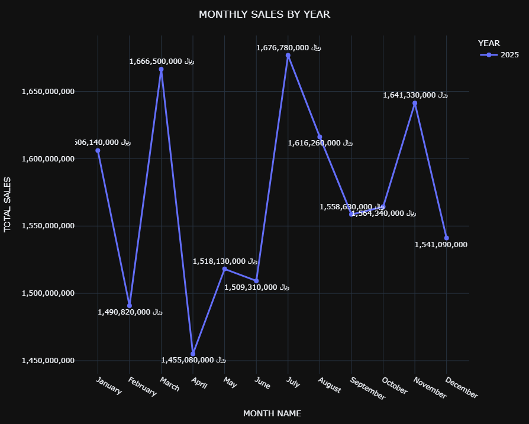

```python
fig = px.line(monthly_sales_profit_by_year, x="MONTH_NAME", y="TOTAL_SALES", markers=True, text="TOTAL_SALES", color="YEAR")

fig.update_traces(texttemplate="ریال %{text:,.0f}", textposition=["top center", "bottom center","top center", "bottom center",
"top center", "bottom center", "top center", "bottom center", "top center", "bottom center", "top center", "bottom center"],
line=dict(width=3), marker=dict(size=8))
fig.update_layout(title="MONTHLY SALES BY YEAR", title_x=0.5, height=700, width=1100, xaxis_title="MONTH NAME", yaxis_title="TOTAL SALES",
hovermode="x unified", template="plotly_dark")
fig.update_yaxes(tickformat=",")

fig.show()
```

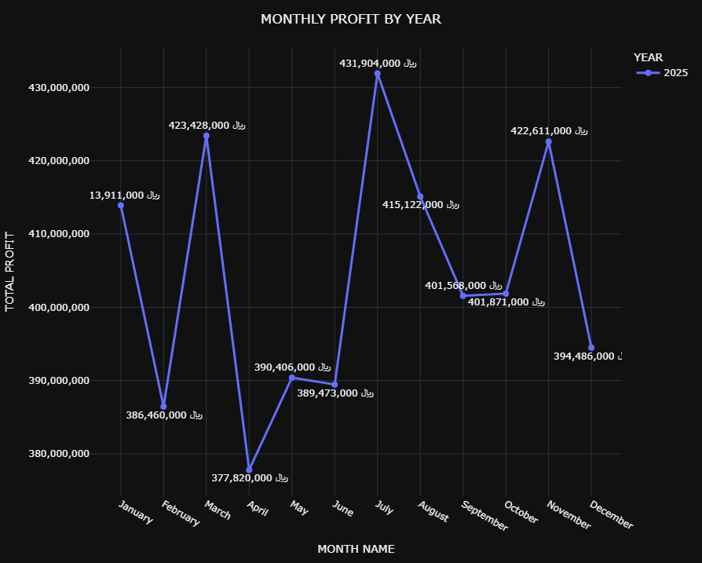

```python
fig = px.line(monthly_sales_profit_by_year, x="MONTH_NAME", y="TOTAL_PROFIT", markers=True, text="TOTAL_PROFIT", color="YEAR")

fig.update_traces(texttemplate="ریال %{text:,.0f}", textposition=["top center", "bottom center","top center", "bottom center",
"top center", "bottom center", "top center", "bottom center", "top center", "bottom center", "top center", "bottom center"],
line=dict(width=3), marker=dict(size=8))
fig.update_layout(title="MONTHLY PROFIT BY YEAR", title_x=0.5, height=700, width=1100, xaxis_title="MONTH NAME", yaxis_title="TOTAL PROFIT",
hovermode="x unified", template="plotly_dark")
fig.update_yaxes(tickformat=",")

fig.show()
```

**SALES & PROFIT BY MONTH**

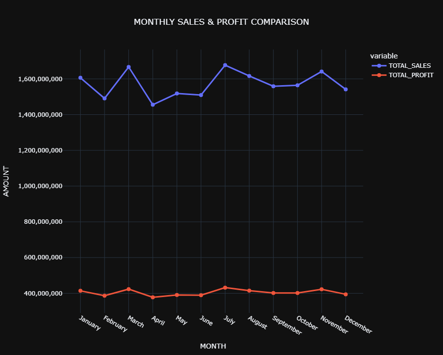

```python
monthly_sales_profit = pd.read_sql("""
SELECT MONTH(OrderDate) AS MONTH_NUM, MONTH_NAME,
SUM(Sales) AS TOTAL_SALES,
SUM(Profit) AS TOTAL_PROFIT
FROM Invoices
GROUP BY MONTH(OrderDate), MONTH_NAME
ORDER BY MONTH_NUM;
""", engine)


fig = px.line(monthly_sales_profit, x="MONTH_NAME", y=["TOTAL_SALES", "TOTAL_PROFIT"], markers=True, title="MONTHLY SALES & PROFIT COMPARISON")
fig.update_traces(line=dict(width=3), marker=dict(size=8))
fig.update_layout(title_x=0.5, height=700, width=1100, xaxis_title="MONTH", yaxis_title="AMOUNT", hovermode="x unified", template="plotly_dark")
fig.update_yaxes(tickformat=",")

fig.show()
```

**TOTAL SALES, TOTAL PROFIT, OVERALL MARGIN & TOTAL ORDERS**

```python
pd.read_sql("""
SELECT SUM(Sales) AS TOTAL_SALES,
SUM(Profit) AS TOTAL_PROFIT,
ROUND(SUM(Profit*100.0)/NULLIF(SUM(Sales),.0),2) AS OVERALL_MARGIN,
COUNT(DISTINCT InvoiceId) AS TOTAL_ORDERS
FROM Invoices
""",engine)
```

|  | TOTAL_SALES | TOTAL_PROFIT | OVERALL_MARGIN | TOTAL_ORDERS |
| --- | --- | --- | --- | --- |
| 0 | 18844410000 | 4849060000 | 25.73 | 14586 |

```python
pd.read_sql("""
SELECT
FORMAT(SUM(Sales * (1 - Discount / 100.0)), 'N0') AS SALES_AFTER_DISCOUNT,
FORMAT(SUM(Sales * (1 - Discount / 100.0)) - (SUM(Sales) - SUM(Profit)),'N0') AS ESTIMATED_PROFIT_AFTER_DISCOUNT
FROM Invoices;

""",engine)
```

|  | SALES_AFTER_DISCOUNT | ESTIMATED_PROFIT_AFTER_DISCOUNT |
| --- | --- | --- |
| 0 | 18,838,759,065 | 4,843,409,065 |

**TOP 3 PRODUCTS BY SALES WITHIN EACH CATEGORY**

```python
pd.read_sql("""
SELECT *
FROM (SELECT P.Category, P.[Sub-Category], P.ProductId, P.ProductName,
SUM(I.Sales)  AS TOTAL_SALES,
SUM(I.Profit) AS TOTAL_PROFIT,
RANK() OVER(PARTITION BY P.Category ORDER BY SUM(I.Sales) DESC) AS SALES_RANK
FROM Invoices AS I
INNER JOIN Products AS P ON P.ProductId = I.ProductId
GROUP BY P.Category, P.[Sub-Category], P.ProductId, P.ProductName) AS A
WHERE SALES_RANK <= 3
ORDER BY Category, SALES_RANK;
""", engine)
```

|  | Category | Sub-Category | ProductId | ProductName | TOTAL_SALES | TOTAL_PROFIT | SALES_RANK |
| --- | --- | --- | --- | --- | --- | --- | --- |
| 0 | آرایشی | آرایش لب | 318 | لوسیون سی‌گل مدل 987 | 69760000 | 18161000 | 1 |
| 1 | آرایشی | آرایش چشم | 132 | ماسک شون مدل 730 | 65700000 | 18392000 | 2 |
| 2 | آرایشی | مراقبت پوست | 253 | خمیر دندان مای مدل 210 | 64870000 | 16575000 | 3 |
| 3 | بهداشتی | بهداشت دهان | 196 | صابون سینره مدل 716 | 90480000 | 21933000 | 1 |
| 4 | بهداشتی | مراقبت بدن | 83 | ریمل شون مدل 673 | 70830000 | 17641000 | 2 |
| 5 | بهداشتی | بهداشت دهان | 402 | ماسک شون مدل 142 | 67720000 | 17059000 | 3 |

**PRODUCTS WITH TOTAL SALES ABOVE AVERAGE**

```python
pd.read_sql("""
SELECT ProductId,
SUM(Sales) AS TOTAL_SALES
FROM Invoices
GROUP BY ProductId
HAVING SUM(Sales) > (SELECT AVG(TOTAL_SALES)
FROM (SELECT ProductId,
SUM(Sales) AS TOTAL_SALES
FROM Invoices
GROUP BY ProductId) AS A)
ORDER BY TOTAL_SALES DESC;

""", engine)
```

|  | ProductId | TOTAL_SALES |
| --- | --- | --- |
| 0 | 196 | 90480000 |
| 1 | 83 | 70830000 |
| 2 | 318 | 69760000 |
| 3 | 402 | 67720000 |
| 4 | 340 | 65750000 |
| ... | ... | ... |
| 231 | 198 | 37970000 |
| 232 | 356 | 37880000 |
| 233 | 228 | 37870000 |
| 234 | 195 | 37840000 |
| 235 | 479 | 37740000 |

236 rows × 2 columns

**DISPLAYING CATEGORY, SUB-CATEGORY & PRODUCTNAME BY PRODUCTID**

```python
pd.read_sql("""
SELECT ProductId, Category,[Sub-Category], ProductName
FROM Products
WHERE ProductId IN (106, 83, 318, 402,340,196);
""", engine)
```

|  | ProductId | Category | Sub-Category | ProductName |
| --- | --- | --- | --- | --- |
| 0 | 83 | بهداشتی | مراقبت بدن | ریمل شون مدل 673 |
| 1 | 106 | آرایشی | مراقبت پوست | ضدآفتاب شون مدل 342 |
| 2 | 196 | بهداشتی | بهداشت دهان | صابون سینره مدل 716 |
| 3 | 318 | آرایشی | آرایش لب | لوسیون سی‌گل مدل 987 |
| 4 | 340 | بهداشتی | مراقبت بدن | صابون لافارر مدل 147 |
| 5 | 402 | بهداشتی | بهداشت دهان | ماسک شون مدل 142 |

```python
TOTAL_CUSTOMERS = pd.read_sql("""
SELECT COUNT(DISTINCT CustomerId) AS TOTAL_CUSTOMERS
FROM customers
""", engine)

TOTAL_SALES = pd.read_sql("""
SELECT SUM(Sales) AS TOTAL_SALES
FROM Invoices
""",engine)

TOTAL_PROFIT = pd.read_sql("""
SELECT SUM(Profit) AS TOTAL_PROFIT
FROM Invoices
""",engine)

TOTAL_ORDERS = pd.read_sql("""
SELECT COUNT(DISTINCT InvoiceId) AS TOTAL_ORDERS
FROM Invoices
""",engine)

OVERALL_MARGIN = pd.read_sql("""
SELECT  ROUND(SUM(Profit*100.0)/NULLIF(SUM(Sales),.0),2) AS OVERALL_MARGIN
FROM Invoices
""",engine)



HTML(f"""
<style>
body{{font-family:Arial,sans-serif;}}
.container{{display:flex; gap:30px; padding:30px; flex-wrap:wrap; justify-content:center; background:black;}}
.card{{width:250px; padding:30px; border-radius:30px; color:pink; text-align:center; background:linear-gradient(150deg, #1a1a1a, #2e2e2e);
box-shadow:4px 4px 10px blue; transition:0.5s;}}
.card:hover{{transform:translateY(-10px) scale(1.05); box-shadow:0 20px 40px green;}}
.title{{font-size:25px; letter-spacing:1px;}}
.value{{font-size:40px; font-weight:bold;}}
</style>

<div class="container">

<div class="card">
<h1 class="title">TOTAL CUSTOMERS</h1>
<h2 class="value">{TOTAL_CUSTOMERS.iloc[0,0]:,}</h2>
</div>

<div class="card">
<h1 class="title">TOTAL SALES</h1>
<h2 class="value">{TOTAL_SALES.iloc[0,0]:,}</h2>
</div>

<div class="card">
<h1 class="title">TOTAL PROFIT</h1>
<h2 class="value">{TOTAL_PROFIT.iloc[0,0]:,}</h2>
</div>

<div class="card">
<h1 class="title">TOTAL ORDERS</h1>
<h2 class="value">{TOTAL_ORDERS.iloc[0,0]:,}</h2>
</div>

<div class="card">
<h1 class="title">OVERALL MARGIN</h1>
<h2 class="value">{OVERALL_MARGIN.iloc[0,0]:,}%</h2>
</div>


</div>
""")
```

TOTAL CUSTOMERS

2,500

TOTAL SALES

18,844,410,000

TOTAL PROFIT

4,849,060,000

TOTAL ORDERS

14,586

OVERALL MARGIN

25.73%